# Week 6: Analysis of longitudinal data

## BPRS data

**Data presented**

The BPRS data is a analysed similarly as in the chapter 9 in the book **MABS (Vehkalahti and Everitt, 2019)**

The BPRS dataset consist of weekly BPRS (brief psychiatric rating scale) measurements of 40 men divided into two treatment groups. There are nine measurements per person of which the first is the baseline measurement and eight are measurements during the follow-up. We can see that weekly BPRS score mainly ranges between 18-95.

```
## [1] "treatment" "subject"   "weeks"     "bprs"      "week"
```

```
## 'data.frame':    360 obs. of  5 variables:
##  $ treatment: int  1 1 1 1 1 1 1 1 1 1 ...
##  $ subject  : int  1 2 3 4 5 6 7 8 9 10 ...
##  $ weeks    : Factor w/ 9 levels "week0","week1",..: 1 1 1 1 1 1 1 1 1 1 ...
##  $ bprs     : int  42 58 54 55 72 48 71 30 41 57 ...
##  $ week     : int  0 0 0 0 0 0 0 0 0 0 ...
```

```
##    treatment      subject          weeks          bprs            week
##  Min.   :1.0   Min.   : 1.00   week0  : 40   Min.   :18.00   Min.   :0
##  1st Qu.:1.0   1st Qu.: 5.75   week1  : 40   1st Qu.:27.00   1st Qu.:2
##  Median :1.5   Median :10.50   week2  : 40   Median :35.00   Median :4
##  Mean   :1.5   Mean   :10.50   week3  : 40   Mean   :37.66   Mean   :4
##  3rd Qu.:2.0   3rd Qu.:15.25   week4  : 40   3rd Qu.:43.00   3rd Qu.:6
##  Max.   :2.0   Max.   :20.00   week5  : 40   Max.   :95.00   Max.   :8
##                                (Other):120
```

```
##    Min. 1st Qu.  Median    Mean 3rd Qu.    Max.
##       0       2       4       4       6       8
```

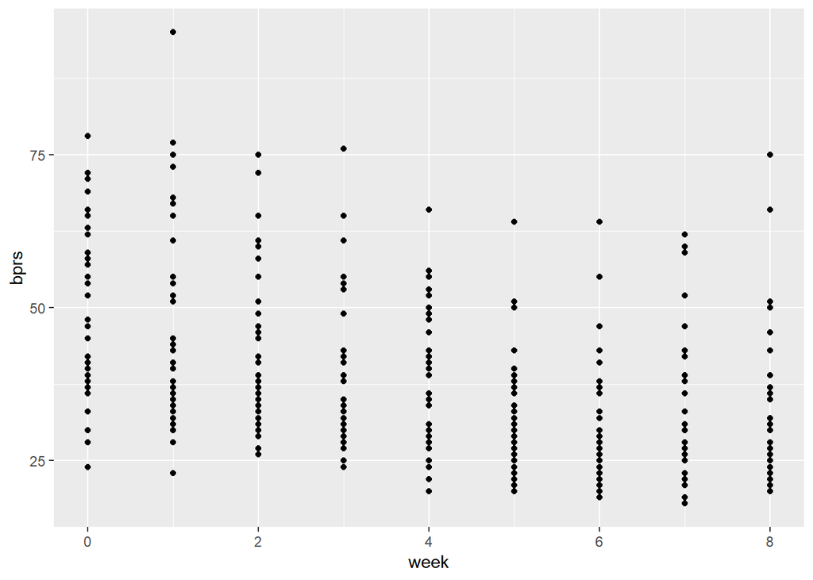

```r
library(ggplot2)
ggplot(B_L, aes(x = week, y = bprs, group = subject)) +
geom_point()
```

**Linear regression with the BPRS data**

First we again ignore the longitudinal format of the data (and several measurements from individuals) and we fit a linear regression model for the BRPS data which tries to resolve how the treatment affect the BPRS.

```r
B_lm <- lm(bprs ~ week + treatment, data = B_L)

# print out a summary of the model
summary(B_lm)
```

```
##
## Call:
## lm(formula = bprs ~ week + treatment, data = B_L)
##
## Residuals:
##     Min      1Q  Median      3Q     Max
## -22.454  -8.965  -3.196   7.002  50.244
##
## Coefficients:
##             Estimate Std. Error t value Pr(>|t|)
## (Intercept)  46.4539     1.3670  33.982   <2e-16 ***
## week         -2.2704     0.2524  -8.995   <2e-16 ***
## treatment2    0.5722     1.3034   0.439    0.661
## ---
## Signif. codes:  0 '***' 0.001 '**' 0.01 '*' 0.05 '.' 0.1 ' ' 1
##
## Residual standard error: 12.37 on 357 degrees of freedom
## Multiple R-squared:  0.1851, Adjusted R-squared:  0.1806
## F-statistic: 40.55 on 2 and 357 DF,  p-value: < 2.2e-16
```

From the linear regression **model summary** we can see that weeks affects the bprs but the treatment does not. You shoud not this model however. Next, we will do a proper analysis.

**liner mixed model analysis**

A proper analysis model for this longitudinal data is linear mixed model with random slope and random intercept. We however, first perform a random intercept model only

```
## Linear mixed model fit by maximum likelihood  ['lmerMod']
## Formula: bprs ~ week + treatment + (1 | subject)
##    Data: B_L
##
##      AIC      BIC   logLik deviance df.resid
##   2748.7   2768.1  -1369.4   2738.7      355
##
## Scaled residuals:
##     Min      1Q  Median      3Q     Max
## -3.0481 -0.6749 -0.1361  0.4813  3.4855
##
## Random effects:
##  Groups   Name        Variance Std.Dev.
##  subject  (Intercept)  47.41    6.885
##  Residual             104.21   10.208
## Number of obs: 360, groups:  subject, 20
##
## Fixed effects:
##             Estimate Std. Error t value
## (Intercept)  46.4539     1.9090  24.334
## week         -2.2704     0.2084 -10.896
## treatment2    0.5722     1.0761   0.532
##
## Correlation of Fixed Effects:
##            (Intr) week
## week       -0.437
## treatment2 -0.282  0.000
```

```
## Linear mixed model fit by maximum likelihood  ['lmerMod']
## Formula: bprs ~ week + treatment + (week | subject)
##    Data: B_L
##
##      AIC      BIC   logLik deviance df.resid
##   2745.4   2772.6  -1365.7   2731.4      353
##
## Scaled residuals:
##     Min      1Q  Median      3Q     Max
## -2.8919 -0.6194 -0.0691  0.5531  3.7976
##
## Random effects:
##  Groups   Name        Variance Std.Dev. Corr
##  subject  (Intercept) 64.8202  8.0511
##           week         0.9608  0.9802   -0.51
##  Residual             97.4307  9.8707
## Number of obs: 360, groups:  subject, 20
##
## Fixed effects:
##             Estimate Std. Error t value
## (Intercept)  46.4539     2.1052  22.066
## week         -2.2704     0.2977  -7.626
## treatment2    0.5722     1.0405   0.550
##
## Correlation of Fixed Effects:
##            (Intr) week
## week       -0.582
## treatment2 -0.247  0.000
```

When we compare the two LMM model created, we can see that the random intercept random slope model is better.

```r
anova(B_rand_i,B_rand_i_s)
```

```
## Data: B_L
## Models:
## B_rand_i: bprs ~ week + treatment + (1 | subject)
## B_rand_i_s: bprs ~ week + treatment + (week | subject)
##            Df    AIC    BIC  logLik deviance  Chisq Chi Df Pr(>Chisq)
## B_rand_i    5 2748.7 2768.1 -1369.4   2738.7
## B_rand_i_s  7 2745.4 2772.6 -1365.7   2731.4 7.2721      2    0.02636 *
## ---
## Signif. codes:  0 '***' 0.001 '**' 0.01 '*' 0.05 '.' 0.1 ' ' 1
```

```
## Linear mixed model fit by maximum likelihood  ['lmerMod']
## Formula: bprs ~ week + treatment + (week | subject) + week * treatment
##    Data: B_L
##
##      AIC      BIC   logLik deviance df.resid
##   2744.3   2775.4  -1364.1   2728.3      352
##
## Scaled residuals:
##     Min      1Q  Median      3Q     Max
## -3.0512 -0.6271 -0.0767  0.5288  3.9260
##
## Random effects:
##  Groups   Name        Variance Std.Dev. Corr
##  subject  (Intercept) 65.0016  8.0624
##           week         0.9688  0.9843   -0.51
##  Residual             96.4699  9.8219
## Number of obs: 360, groups:  subject, 20
##
## Fixed effects:
##                 Estimate Std. Error t value
## (Intercept)      47.8856     2.2522  21.262
## week             -2.6283     0.3589  -7.323
## treatment2       -2.2911     1.9090  -1.200
## week:treatment2   0.7158     0.4010   1.785
##
## Correlation of Fixed Effects:
##             (Intr) week   trtmn2
## week        -0.650
## treatment2  -0.424  0.469
## wek:trtmnt2  0.356 -0.559 -0.840
```

```
## Data: B_L
## Models:
## B_rand_i_s: bprs ~ week + treatment + (week | subject)
## B_rand_interact: bprs ~ week + treatment + (week | subject) + week * treatment
##                 Df    AIC    BIC  logLik deviance  Chisq Chi Df Pr(>Chisq)
## B_rand_i_s       7 2745.4 2772.6 -1365.7   2731.4
## B_rand_interact  8 2744.3 2775.4 -1364.1   2728.3 3.1712      1    0.07495
##
## B_rand_i_s
## B_rand_interact .
## ---
## Signif. codes:  0 '***' 0.001 '**' 0.01 '*' 0.05 '.' 0.1 ' ' 1
```

**Plot observed and fitted values**

Next we just want to plot the observed and fitted bprs values. For the fitted model values, we’ll use the random intercept random slope model without interction-term. ** I can not get this work with BPRS data** propably because **subject** is not a unique number that it should be when analysing human data. If I see two same subject numbers I assume that they are the same person! I don’t understand how they are different people with differing treatment in this dataset..

```r
#ggplot(B_L, aes(x = week, y = bprs, group =subject)) +
#  geom_line(aes(alpha = treatment))
#  scale_x_continuous(name = "Time (weeks)", breaks = seq(0,8,2)) +
#  scale_y_continuous(name = "Observed bprs (points) ") +
#  theme(legend.position = "top")
# this not working
```

## RATS data

Unfortunately I have ony time for a quick LMM with the RATS-data (3 groups, weight measurements). So here you go, results from LMM checking if group affect the weight change. And yes, this can be seen, and group affect significanly the rate of weight change (model with interaction better).

```r
#THIS CODE WORKING IN RSTUDIO but when knitting.. "data" not found, and some variables missing etc blaa  #blaa. I put # because othewise it destroys knitting this whole document...
#RATS <- read.table("~/Tyojuttuja/opinnot/GitHub/IODS-project/data/rats_long.txt", header=T, sep = "\t")
#str(RATS)

#factor variables
#RATS$ID <- factor(RATS$ID)
#RATS$Group <- factor(RATS$Group)

# create a random intercept and random slope model
#RATS_ref1 <- lmer(Weight ~ Time + Group + (Time | ID), data = RATS, REML = FALSE)
#
#summary(RATS_ref1)

# create a random intercept and random slope model with the interaction
#RATS_ref2 <- lmer(Weight ~ Group + Time + (Time|ID) +Time*Group, REML= FALSE, data= RATS)

#summary(RATS_ref2)

# perform an ANOVA test on the two models
#anova(RATS_ref2, RATS_ref1)

#Data: RATS
#Models:
#RATS_ref1: Weight ~ Time + Group + (Time | ID)
#RATS_ref2: Weight ~ Group + Time + (Time | ID) + Time * Group
#          Df    AIC    BIC  logLik deviance  Chisq Chi Df Pr(>Chisq)
#RATS_ref1  8 1194.2 1219.6 -589.11   1178.2
#RATS_ref2 10 1185.9 1217.6 -582.93   1165.9 12.361      2    0.00207 **
#---
#Signif. codes:  0 ‘***’ 0.001 ‘**’ 0.01 ‘*’ 0.05 ‘.’ 0.1 ‘ ’ 1
```